# EDA Swiftkey - Capstone Project

Mathias Barat

21/09/2020

### Task1 and Task2 of the Data Science Capstone from JHU

# 1 - SYNOPSIS

Swiftkey dataset. The analysis and goal is to help Swiftkey company to predict words when users type on their keyboard. The prediction must be done from 1, 2 or 3 successive words entered.

The present document is: * giving an overview of the dataset used * taking assumptions regarding the sampling approach as the dataset is quite big * making an EDA * giving some clues for the predictive model I will create

```r
url <- "https://d396qusza40orc.cloudfront.net/dsscapstone/dataset/Coursera-SwiftKey.zip"
```

# 2 - DATA-PREPROCESSING

### GET THE DATASET

Download:

```r
if (!dir.exists("data/")){dir.create("data/")}
if (!file.exists("data/Cousera-swiftkey.zip")){
  download.file(url, destfile = "data/Cousera-swiftkey.zip")
}
```

Unzip:

```r
if (!dir.exists("final/")){
  unzip("data/Cousera-swiftkey.zip")
}
rm(list = ls())
```

### OVERVIEW OF THE DATASET

The dataset is from a corpus called HC Corpora collected by a web crawler.

The dataset is composed of 4 folders :

- de_DE : German language text files
- en_US : English language text files
- fi_FI : Finns language text files
- ru_RU : Russian language text files

In each folder we can find 3 files corresponding to compilation of web published texts which have been gathered from : * Blogs websites * News website * Twitter

Only english files will be used in the following study.

### Natural Language Processing (NLP)

The Natural language processing is a domain of data science developped to analyse the human languages. * https://en.wikipedia.org/wiki/Natural_language_processing

Tools such as Text Mining (tm package in R) has been developped to process the human text data. * https://cran.r-project.org/web/views/NaturalLanguageProcessing.html

Machine learning methods are now a standard in the domain.The present analysis will use it.

The NLP can helps to analyse the languages for different purposes such as :

Text and speech processing * Optical character recognition (OCR) * Speech recognition * Speech segmentation * Text-to-speech * Word segmentation (Tokenization)

Morphological analysis * Lemmatization * Morphological segmentation * Part-of-speech tagging * Stemming

Syntactic analysis * Grammar induction * Sentence breaking (also known as “sentence boundary disambiguation”) * Parsing

Lexical semantics (of individual words in context) * Lexical semantics * Distributional semantics * Named entity recognition (NER). * Sentiment analysis (see also multimodal sentiment analysis). * Terminology extraction * Word sense disambiguation

Relational Semantics * Relationship extraction * Semantic Parsing * Semantic Role Labelling (see also implicit semantic role labelling below)

Discourse (semantics beyond individual sentences) * Coreference resolution * Discourse analysis * Implicit Semantic Role Labelling * Recognizing Textual entailment

Higher-level NLP applications * Book generation * Machine translation * Natural language understanding (NLU) * Question answering

The training I had during the specialization will help me with : * Preprocessing of the data : preparation of the dataset to be usable by ML and associated Data science tools (split, case, cleaning, removing ) * Analysis of the data : vectorization, bagging… * Exploitation of the results

I will use also other data sources such as : * Other NLP processing as example on Kaggle for instance * Find datasets and their reproducible analysis in each language that can help me with the specificities of each. * wordnet and similar databases * list of profanes words

### Loading the data

```r
load_data <- function(){
  # The 2 files are okay to be opened directly with UTF-8
  con <- file("final/en_US/en_US.blogs.txt", "r")
  dblog <<- readLines(con, encoding = "UTF-8", skipNul = TRUE, warn = FALSE)
  close(con)

  con <- file("final/en_US/en_US.twitter.txt","r")
  dtwit <<- readLines(con, encoding = "UTF-8", skipNul = TRUE, warn = FALSE)
  close(con)

  # Binary mode because the file has special characters, the readlines method was blocked with the previous method
  con <- file("final/en_US/en_US.news.txt", open="rb")
  dnews <<- readLines(con, encoding = "UTF-8",skipNul = TRUE, warn = FALSE)
  close(con)
}
```

### sizes and format of the dataset

```r
if (!file.exists("data/dat_sum.txt")){
  # Load the dataset
  load_data()

  # Intitalize the data summary
  dat_sum <- file.info(dir("final/en_US/",recursive = TRUE, full.names = TRUE))[1]/1024^2
  colnames(dat_sum) <- "Size_in_Mo"
  dat_sum$Number_Of_Lines <- c(length(dblog),length(dnews),length(dtwit))
  dat_sum$Number_of_Words <- c( sum(sapply(gregexpr("\\S+", dblog), length)),
                      sum(sapply(gregexpr("\\S+", dnews), length)),
                      sum(sapply(gregexpr("\\S+", dtwit), length)))

  dat_sum$Mean_words_per_line <- c(mean(sapply(gregexpr("\\S+", dblog), length)),
                          mean(sapply(gregexpr("\\S+", dnews), length)),
                          mean(sapply(gregexpr("\\S+", dtwit), length)))

  dat_sum$Max_Line <- sapply(list(dblog, dnews, dtwit), function(x){max(unlist(lapply(x, function(y) nchar(y))))})

  dat_sum$File <- c("Blogs",
                    "News",
                    "Twitter")
  dat_sum <- as.data.frame(dat_sum)
  write.table(dat_sum, "data/dat_sum.txt")
}
```

### Sampling

I will sample 0.5% of the Blogs data, 1% of the News data and 0.5% of the Twitter data, also I have created a reduced Sample dataset sample to work my algorythm and save time during my investigations at the end of the chunk:

```r
if (!file.exists("data/dataSample.txt")){
  load_data()
  set.seed(333)
  dat_sum <- read.table("data/dat_sum.txt")
  dat_sum$Percentage <- c(0.005,0.01,0.005)
  dat_sum$Sample_size <- dat_sum$Number_Of_Lines* dat_sum$Percentage
  write.table(dat_sum, "data/dat_sum.txt")

  # Final Sample dataset
  dblogS <- dblog[rbinom(n = dat_sum$Sample_size[1],
                         size = 1,
                         prob = dat_sum$Percentage[1]) == 1]
  dnewsS <- dnews[rbinom( n = dat_sum$Sample_size[2],
                          size = 1,
                          prob = dat_sum$Percentage[2]) == 1]
  dtwitS <- dtwit[rbinom( n = dat_sum$Sample_size[3],
                          size = 1,
                          prob = dat_sum$Percentage[3]) == 1]


  # Creation of one frame
  dataSample <- c(dblogS,dnewsS, dtwitS)

  # clean non latin characters
  dataSample <- iconv(dataSample, "latin1", "ASCII", sub="")

  # Save my sample file
  write(dataSample, "data/dataSample.txt")
  write(sample(dataSample,size = 3000), "data/dataSampleWIP.txt")
}
rm(list = ls())
```

### Cleaning and Profanes words removal and Tokens Creation

In order to ameliorate the dataset. I have decided to successively convert the sentences in Tokens and convert these into word tokens. By this process I will increase the accuracy of my model as the ngrams won’t include the sequences of words onto 2 sentences.

```r
library(quanteda)
Corpus <- readLines("data/dataSampleWIP.txt")
Corpus <- readLines("data/dataSample.txt")
Corpus <- corpus(Corpus)

# Get list of bad words to be excluded
url_EN_prof = "https://raw.githubusercontent.com/rominf/profanity-filter/master/profanity_filter/data/en_profane_words.txt"
if (!file.exists("data/prof_en.txt")){
  download.file(url_EN_prof, destfile = "data/prof_en.txt")
}
con <- file("data/prof_en.txt")
prof_en <- readLines(con)
names(prof_en)<-"Bad Words"
close(con)
rm(con, url_EN_prof)

# Sentence tokens Creation
myTokens <- tokens(Corpus, remove_punct = TRUE, remove_numbers = TRUE, remove_url = TRUE, remove_symbols = TRUE, remove_separators = TRUE, what = "sentence")

# Lower
myTokens <- tokens_tolower(myTokens)

# Word tokens creation:
myTokens <- tokens(attr(myTokens, "types"), remove_punct = TRUE, remove_numbers = TRUE, remove_url = TRUE, remove_symbols = TRUE, remove_separators = TRUE, what="word")

# Pattern creation for suppressing (emails, urls, twitters account...)
patt <- c("\\b[A-Z a-z 0-9._ - ]*[@](.*?)[.]{1,3} \\b", # email
          "(ftp|http)(s?)://.*\\b",                     # http
          "[@][a-zA-Z]{1,25}")                          # twitt
myTokens <- tokens_select(myTokens,
                          pattern = patt,
                          selection = "remove",
                          valuetype = "regex")

# Profanities
myTokens <- tokens_remove(myTokens, prof_en)

# Stopword
myTokensSW <- tokens_remove(myTokens,stopwords(language = "en"))

# Whitespaces removal
myTokens <- tokens_remove(myTokens, " ")
myTokensSW <- tokens_remove(myTokensSW, " ")

length(attr(myTokens, "types"))
```

```
## [1] 46117
```

```r
length(attr(myTokensSW, "types"))
```

```
## [1] 45945
```

```r
rm(Corpus, dataSample, patt, prof_en)
```

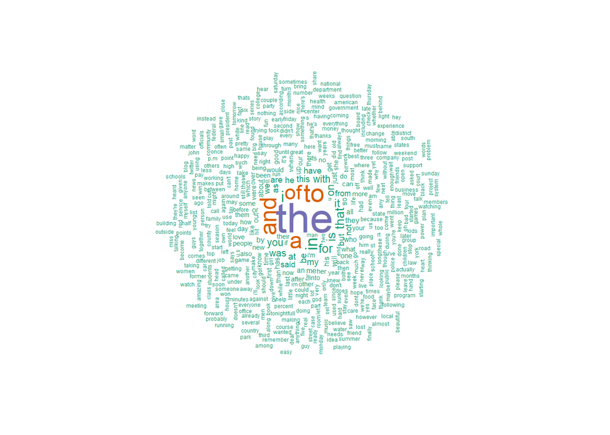

```r
textplot_wordcloud(dfm(myTokens), min_count = 20, random_order = FALSE,
                   rotation = .5,
                   colors = RColorBrewer::brewer.pal(2,"Dark2"))
```

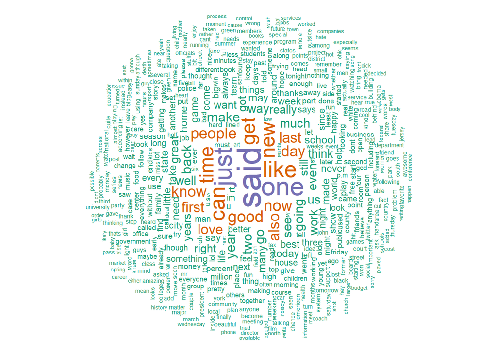

```r
textplot_wordcloud(dfm(myTokensSW), min_count = 20, random_order = FALSE,
                   rotation = .5,
                   colors = RColorBrewer::brewer.pal(2,"Dark2"))
```

```r
rm(myTokensSW)
```

# 3 - Exploratory Data Analysis

## Distribution of words

### Ngrams with stopwords

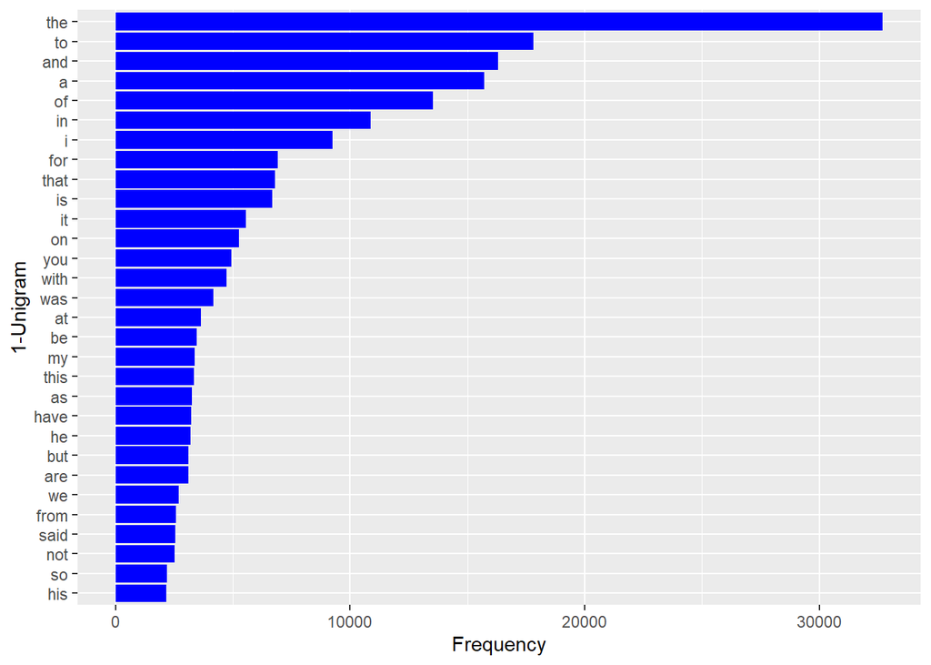

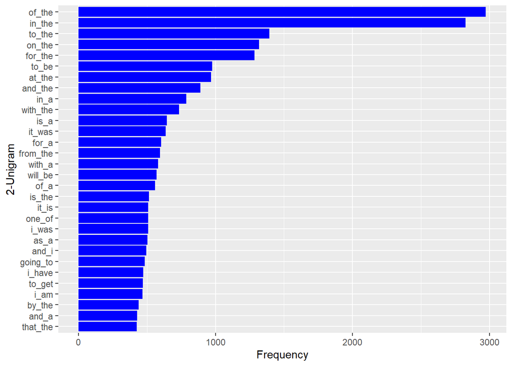

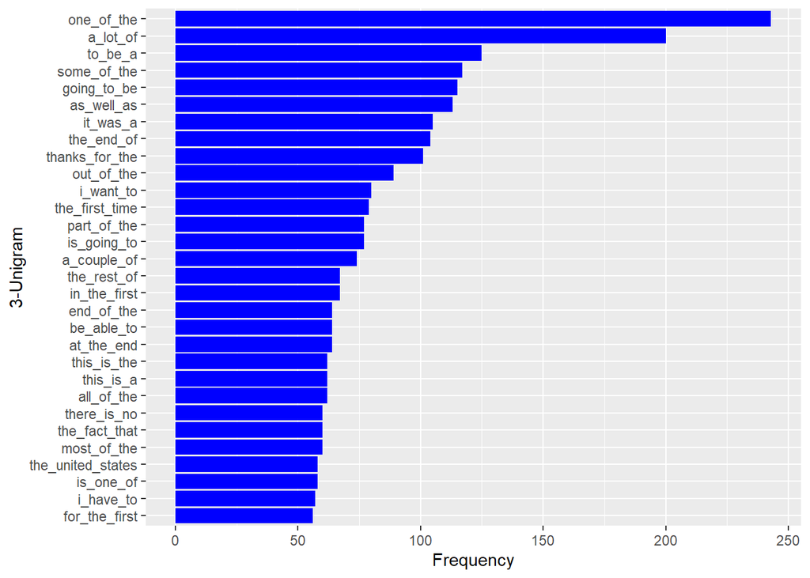

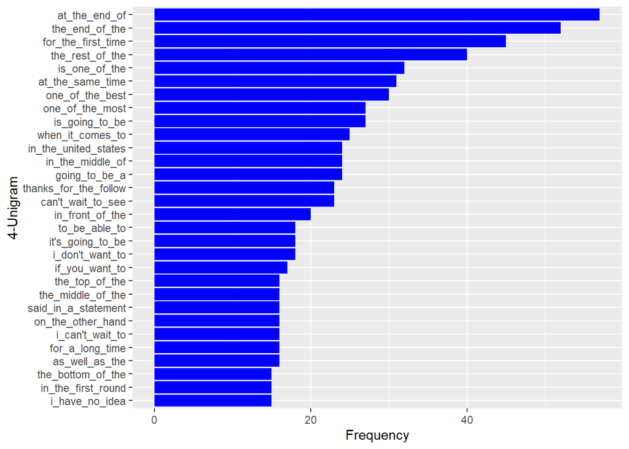

```r
library(ggplot2)
for (i in seq(4)){
  mydfm <- dfm(tokens_ngrams(myTokens,
                             n = i,
                             skip = 0L,
                             concatenator = "_"))
  mygram <- paste(as.character(i),"-Unigram", sep = "")
  topf <- as.data.frame(topfeatures(mydfm,30),optional = TRUE)
  colnames(topf) <- "Count"
  topf$ngram <- rownames(topf)
  g <- ggplot(data=topf, aes(x=Count, y = reorder(ngram, Count, decreasing=FALSE)))+
            geom_col( stat = "Identity", fill="blue" ) +
            ylab(mygram) +
            xlab( "Frequency" )
  print(g)
}
```

```r
rm(mydfm, g, topf, i, mygram)
```

## Number of words for 50% and 90% of the frequencies

texstat_frequency is all we need !

```r
mydfm1.statf <- textstat_frequency(dfm(myTokens))

j <- 0
nfeatures <- sum(mydfm1.statf $frequency)
t <- TRUE
for(i in 1:length(mydfm1.statf $frequency)) {
  j <- j + mydfm1.statf $frequency[i]
  if(j >= 0.5*nfeatures & t){
    word50 <-i
    t<- FALSE
    }
  if(j >= 0.9*nfeatures){
    word90 <-i
    break}
}
print (paste("words to reach 50%:", word50))
```

```
## [1] "words to reach 50%: 149"
```

```r
print (paste("words to reach 90%:", word90))
```

```
## [1] "words to reach 90%: 7946"
```

```r
rm(mydfm1.statf)
```

## Foreign words

Remove from my tokens all the “non english” words, but also the typo errors. Really relevant for our model as we will work only from a knwn corpus

```r
myTokens.foreign <- tokens_select(myTokens, names(data_int_syllables), selection = "remove")
topfeatures(dfm(myTokens.foreign),30)
```

```
##        a       rt      lol     dont      p.m    thats    didnt      ive
##    15704      438      273      258      199      138      117       93
## facebook     haha   doesnt      hes      a.m   theres    youre    wasnt
##       86       85       83       82       78       68       64       61
##      omg  couldnt congrats      nba   tweets   theyre      nfl     ncaa
##       54       47       47       46       45       39       39       37
##     lmao     weve     pics  wouldnt      1st      ppl
##       37       36       34       34       34       33
```

```r
myWordKeep <- as.data.frame(topfeatures(dfm(myTokens.foreign),100))
colnames(myWordKeep) <- "frequency"
myWordKeep$word <- rownames(myWordKeep)
rownames(myWordKeep)<- seq(1:length(myWordKeep$word))
# Suppression of bad formulation such as "hasnt" or "shes" from the 100 top features.
# I kept some acronyms and brand names such as "facebook", "avengers"
# "lol", "idk" specific internet acronyms are kept also
myWordKeep <- c("rt","dont","thats","didnt","ive","doesnt","hes","theres","youre","wasnt","couldnt","theyre","weve","wouldnt","1st","ppl")
dict <- append(names(data_int_syllables), myWordKeep)

myTokens <- tokens_select(myTokens, dict, selection = "keep")
rm(myTokens.foreign, myWordKeep)
```

### Reducing the number of words in the dictionary

A simple and quick solution would be to suppress all the low frequency words from the dictionary. For instance, all the 1 or 2 time

```r
topfeatures(dfm(myTokens),10, decreasing = FALSE)
```

```
## uncontrolled  unregulated        sison        greed exploitation       melody
##            1            1            1            1            1            1
##   barricades       jigsaw  subtraction    crossword
##            1            1            1            1
```

With this simple approach, I test to threshold the dfm for low frequencies features:

```r
freq <- ""
percentage <- ""
for (i in seq(3,10)){
  mydfm <- dfm_trim(
    dfm(myTokens),
    min_termfreq = i
  )

  # Frequency
  percentage_saved <-  (nfeat(dfm(myTokens)) - nfeat(mydfm))/ nfeat(dfm(myTokens))
  freq <- append(freq, i)
  percentage <- append(percentage, percentage_saved*100)
  lowfreq_features <- as.data.frame(cbind(percentage, freq))
}
lowfreq_features
```

```
##         percentage freq
## 1
## 2 54.3422904241774    3
## 3 63.0503250016753    4
## 4 68.5116933592441    5
## 5 72.4988273135429    6
## 6 75.3668833344502    7
## 7 77.8060711653153    8
## 8 79.7125242913623    9
## 9 81.3073778730818   10
```

```r
rm(mydfm, lowfreq_features, i, j, myWordKeep, nfeatures, percentage, percentage_saved, word50, word90, t, dict, freq)
```

# 5 - Conclusions of the EDA

This exercise taught me 2 things: * starting to understand the NLP and the libraries associated. I changed in the middle and I started to use Quanteda as I felt it more efficient and easy to us (for now). * seeing that we **really** have to take care of the memory usage of the computer. When the dataset is getting bigger, the time to compute can be incredibly long and really pain in the ass. So finding the good mitigation for the sample size is important. I managed also to create a lot of “Checkpoints” in my pogram to clean the memory and start fresh with local files I am creating all along.

# 6 - MODEL

## Generate ngrams

```r
library(tidyr)
for (i in seq(4)){
  ts <- textstat_frequency(dfm(tokens_ngrams(myTokens,
                                                n = i,
                                                skip = 0L,
                                                concatenator = "_")))

  # Create 1 column by word
  words <- as.data.frame(ts$feature)
  colnames(words) <- "words"
  ts  <- cbind(ts,(separate(data = words,
                             col = words,
                             sep = "_",
                             remove = TRUE,
                             into = c("word1", "word2", "word3", "word4"))))
  ts <- ts[,!(names(ts) %in% c("group", "X", "feature", "rank"))]
  write.csv(ts, file = paste("data/",i,"-ngrams.csv", sep = ""))
}
rm(ts, words, i)
```

```r
for (i in seq(4)){
  myFile <- paste("data/", i, "-ngrams.csv", sep="")
  read.csv(file = myFile)
  if (i==1){nam <- "uni"}
  if (i==2){nam <- "bi"}
  if (i==3){nam <- "tri"}
  if (i==4){nam <- "quadri"}
  assign(paste(nam,"grams", sep=""),read.csv(file = myFile))
}
```

```r
library(dplyr)
predict <- function(input){

  ### Clean the input data
  input <- tolower(gsub("[[:punct:]]","",input))
  words <- strsplit(input," ")[[1]]
  words <- words [! words %in% ""]
  if (length(words) > 3){
      words <- words[-(1:(length(words)-3))]
  }

  ### Determine the lenghts and initialize my result panel
  n = length(words)
  r <- data.frame(Word=as.character(),Score=as.integer(),stringsAsFactors=FALSE)

  ### For 3 words
  if (n == 3){
    result <- quadrigrams %>% filter(word1 == words[1])%>% filter(word2 == words[2])%>% filter(word3 == words[3])
    sumcount <- sum(result$frequency)
    result <- result %>% top_n(5, frequency) %>% mutate(Score = frequency / sumcount) %>% select(word4, Score)
    colnames(result) <- c("Word", "Score")
    if (dim(result)[1] < 5){
        words <- words[-1]
    }
    r <- rbind(r, result)
  }

  ### For 2 words
  if (n == 2){
    result <- trigrams %>% filter(word1 == words[1])%>% filter(word2 == words[2])
    sumcount <- sum(result$frequency)
    result <- result %>% top_n(5, frequency) %>% mutate(Score = frequency / sumcount * 0.4^(n-2)) %>% select(word3, Score)
    colnames(result) <- c("Word", "Score")
    if (dim(result)[1] < 5){
        words <- words[-1]
    }
    r <- rbind(r, result)
  }

  ### For 1 word
  if (n == 1){
    result <- bigrams %>% filter(word1 == words[1])
    sumcount <- sum(result$frequency)
    result <- result %>% top_n(5, frequency) %>% mutate(Score = frequency / sumcount * 0.4^(n-1)) %>% select(word2, Score)
    colnames(result) <- c("Word", "Score")
    if (dim(result)[1] < 5){
        words <- words[-1]
    }
    r <- rbind(r, result)
  }

    ### For 0 word
  if (n == 0){
    result <- unigrams
    sumcount <- sum(result$frequency)
    result <- result %>% top_n(5, frequency) %>% mutate(Score = frequency / sumcount * 0.4^(n)) %>% select(word1, Score)
    colnames(result) <- c("Word", "Score")
    if (dim(result)[1] < 5){
        words <- words[-1]
    }
    r <- rbind(r, result)
  }

input
r
}

testlist <- list("one of the", "trump", "she is", "danger", "dangerous", "batman", "pour", "", "lol")
lapply(testlist, predict)
```

```
## [[1]]
##      Word      Score
## 1    best 0.12295082
## 2    most 0.11065574
## 3 biggest 0.02868852
## 4  things 0.02459016
## 5   first 0.02459016
##
## [[2]]
##      Word Score
## 1   power  0.25
## 2      co  0.25
## 3 despair  0.25
## 4    said  0.25
##
```

[output cut: 78 more lines]